# Презентация по лабораторной работе № 3

Дискреционное разграничение прав в Linux. Два пользователя

Неустроева И.Н.

Российский университет дружбы народов, Москва, Россия

11 марта 2025

# Информация

## Докладчик

- Неустроева Ирина Николаевна
- студентка группы НБИ 02-23
- Российский университет дружбы народов
- https://inneustroeva.github.io/ru/

# Вводная часть

## Актуальность

Навыки работы с атрибутами, создание нескольких учетных записей пользователя, а также навык установки и ограничения прав доступа в ОС - неотьемлемая часть навыков специалиста в области ИТ

## Цели и задачи

Получение практических навыков работы в консоли с атрибутами файлов для групп пользователей

## Материалы и методы

- Процессор `pandoc` для входного формата Markdown
- Результирующие форматы
  - `pdf`
  - `html`
- Автоматизация процесса создания: `Makefile`

# Ход работы

## Создание нового пользователя

Переключившись на учетную запись администратора, Создали второго пользователя guest2

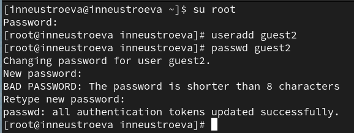

## Добавлене нового пользователя в группу

Добавили пользователя guest2 в группу guest командой: gpasswd -a guest2 guest

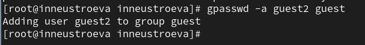

## Вход в систему от двух пользователей

Осуществили вход в систему от двух пользователей на двух разных консолях: guest на первой консоли и guest2 на второй консоли.

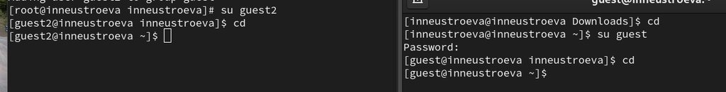

## Уточнение, в какие группы входит пользователь

Уточнили имя нашего пользователя, его группу, кто входит в неё и к каким группам принадлежит он сам.

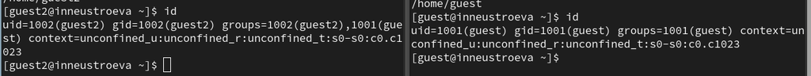

От имени пользователя guest2 выполнили регистрацию пользователя guest2 в группе guest командой: newgrp guest

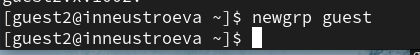

## Разрешения всех действий в директории для пользователей группы

От имени пользователя guest изменили права директории /home/guest, разрешив все действия для пользователей группы:

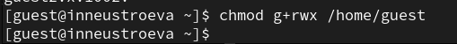

## Снятие всех атрибутов дириктории

От имени пользователя guest сняли с директории /home/guest/dir1 все атрибуты

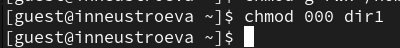

# Выводы